# CS422: Decision Trees using rpart

Vijay K. Gurbani, Ph.D., Illinois Institute of Technology

##### Make sure you install the following packages:

##### > install.packages(c(“rpart”, “rpart.plot”, “caret”, “e1071”, “knitr”, “ROCR”))

# Decision Tree construction and introspection

```r
library(rpart)
library(caret)
library(rpart.plot)
library(ROCR)
rm(list=ls())
setwd("~/Desktop/Assignments&Coursework/422/Hw-2-March4/")
options("digits"=3)
# Load the Diabetes dataset
diabetes <- read.csv("diabetes-mod.csv", header=T, sep=",", comment.char = '#')
head(diabetes)
```

|  | preg | plas | pres | skin | insu | mass | pedigree | age | label |
| --- | --- | --- | --- | --- | --- | --- | --- | --- | --- |
| 1 | 6 | 148 | 72 | 35 | 0 | 33.6 | 0.627 | 50 | 1 |
| 2 | 8 | 183 | 64 | 0 | 0 | 23.3 | 0.672 | 32 | 1 |
| 3 | 0 | 137 | 40 | 35 | 168 | 43.1 | 2.288 | 33 | 1 |
| 4 | 3 | 78 | 50 | 32 | 88 | 31.0 | 0.248 | 26 | 1 |
| 5 | 2 | 197 | 70 | 45 | 543 | 30.5 | 0.158 | 53 | 1 |
| 6 | 8 | 125 | 96 | 0 | 0 | 0.0 | 0.232 | 54 | 1 |

#### Split the data in a 80-20 (train-test) ratio.

```r
set.seed(100)
index <- sample(1:nrow(diabetes), size=0.2*nrow(diabetes))
test <- diabetes[index, ]
train <- diabetes[-index, ]
```

#### Build the decision tree model using all predictor variables. If you only wanted to use, say, preg and plas predictor variables, you would instead specify the formula as **label ~ preg+plas**.

#### Note that we build the model on the training data *(data = train)*

```r
model <- rpart(label ~ ., method="class", data=train)
```

#### Visualize the decision tree

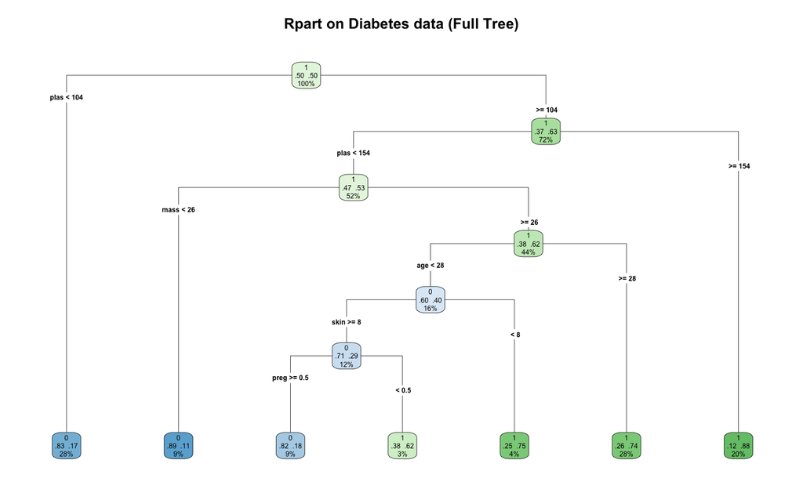

```r
rpart.plot(model, extra=104, fallen.leaves = T, type=4, main="Rpart on Diabetes data (Full Tree)")
```

#### Inspect the model you created for more information.

```r
summary(model)
```

```
Call:
rpart(formula = label ~ ., data = train, method = "class")
  n= 431

      CP nsplit rel error xerror   xstd
1 0.3721      0     1.000  1.093 0.0481
2 0.0674      1     0.628  0.684 0.0458
3 0.0605      3     0.493  0.660 0.0454
4 0.0372      4     0.433  0.614 0.0445
5 0.0140      5     0.395  0.479 0.0412
6 0.0100      6     0.381  0.507 0.0420

Variable importance
    plas     mass      age     preg     skin     pres     insu pedigree
      53       18       10        7        5        3        3        2

Node number 1: 431 observations,    complexity param=0.372
  predicted class=1  expected loss=0.499  P(node) =1
    class counts:   215   216
   probabilities: 0.499 0.501
  left son=2 (120 obs) right son=3 (311 obs)
  Primary splits:
      plas < 104    to the left,  improve=37.20, (0 missing)
      age  < 28.5   to the left,  improve=27.80, (0 missing)
      mass < 29.8   to the left,  improve=21.70, (0 missing)
      preg < 6.5    to the left,  improve=16.70, (0 missing)
      pres < 69     to the left,  improve= 9.13, (0 missing)
  Surrogate splits:
      mass     < 22     to the left,  agree=0.731, adj=0.033, (0 split)
      pedigree < 0.0865 to the left,  agree=0.731, adj=0.033, (0 split)

Node number 2: 120 observations
  predicted class=0  expected loss=0.167  P(node) =0.278
    class counts:   100    20
   probabilities: 0.833 0.167

Node number 3: 311 observations,    complexity param=0.0674
  predicted class=1  expected loss=0.37  P(node) =0.722
    class counts:   115   196
   probabilities: 0.370 0.630
```

[output cut: 90 more lines]

```

Node number 53: 16 observations
  predicted class=1  expected loss=0.25  P(node) =0.0371
    class counts:     4    12
   probabilities: 0.250 0.750

Node number 104: 38 observations
  predicted class=0  expected loss=0.184  P(node) =0.0882
    class counts:    31     7
   probabilities: 0.816 0.184

Node number 105: 13 observations
  predicted class=1  expected loss=0.385  P(node) =0.0302
    class counts:     5     8
   probabilities: 0.385 0.615
```

# Decision tree prediction

#### Now, let’s run predictions using the fitted model. Recall that we have a test dataset that contains 20% of our data. We use the fitted model on this test dataset to see how well the model works.

```r
pred <- predict(model, test, type="class")
```

#### pred now contains the predictions; if we take a look at a few of them, this is what we will see:

```r
head(pred)
```

```
166 139 297  31 251 258
  0   1   0   0   1   0
Levels: 0 1
```

#### Above, the first line is the index of the observation relative to the diabetes dataset (i.e., the first observation in the test dataset corresponds to the 166th observation in the diabetes dataset). Our model is predicting that the first observation of the test dataset will be predicted as 0, the second observation as 1, and so on.

#### Let’s see the true labels in the test dataset:

```r
head(test$label)
```

```
[1] 1 1 0 1 1 1
```

#### Hmmm … looks like the model matched 3 predictions out of the 6 shown.

#### Let’s create a confusion matrix. We will do so in two ways. First, we will create the confusion matrix manually, and then we will use the package caret’s confusionMatrix() method.

```r
# How did we do?  Let's create a confusion matrix manually first.  Let's figure
# out how many observations in our test set were positive and negative.  These
# are the true labels.
total_pos <- sum(test[,9] == 1)
total_neg <- sum(test[,9] == 0)
# Now, let's see how many of the predicted observations that were positive
# actually matched the true labels.
tp <- sum(test[,9] == 1 & pred == 1)
tn <- sum(test[,9] == 0 & pred == 0)
table(pred, test[,9]) # Manual confusion matrix
```

```
pred  0  1
   0 39 11
   1 16 41
```

```r
confusionMatrix(pred, test)
```

[output not shown]

#### Here is the ROC curve for the test data. We will also print the AUC at the end.

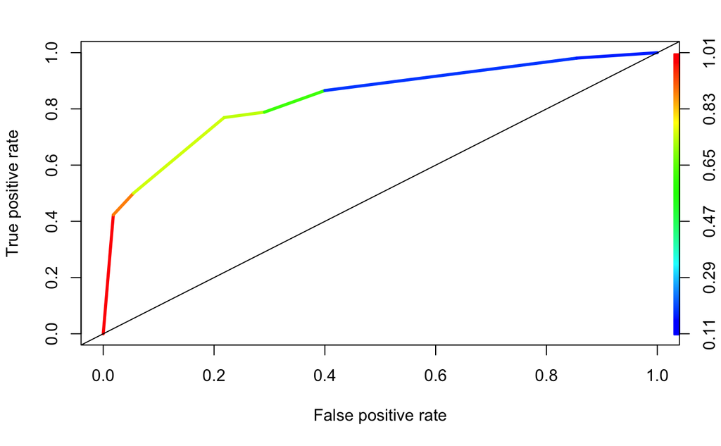

```r
# ROC curve
pred.rocr <- predict(model, newdata=test, type="prob")[,2]
f.pred <- prediction(pred.rocr, test$label)
f.perf <- performance(f.pred, "tpr", "fpr")
plot(f.perf, colorize=T, lwd=3)
abline(0,1)
```

```r
auc <- performance(f.pred, measure = "auc")
cat(paste("The area under curve (AUC) for this model is ", round(auc@y.values[[1]], 3)))
```

```
The area under curve (AUC) for this model is  0.835
```

#### In the code chunk above, note that when we call predict(), we specify the parameter *type=“prob”*. This, then, returns us the probability of how confident the model is of its prediction. Let’s print the first few probabilities. To make the output attractive, I have created a data frame that has 3 columns: True label, Predicted label, and probability.

```r
tmp.df <- data.frame(True_Label=head(test$label),
                     Predicted_Label=head(pred),
                     Probability=head(pred.rocr))
tmp.df
```

|  | True_Label | Predicted_Label | Probability |
| --- | --- | --- | --- |
| 166 | 1 | 0 | 0.167 |
| 139 | 1 | 1 | 0.884 |
| 297 | 0 | 0 | 0.184 |
| 31 | 1 | 0 | 0.167 |
| 251 | 1 | 1 | 0.736 |
| 258 | 1 | 0 | 0.184 |

# Decision Tree pruning

#### To prune the tree, first display the complexity table.

```r
options("digits"=5)
printcp(model)
```

```
Classification tree:
rpart(formula = label ~ ., data = train, method = "class")

Variables actually used in tree construction:
[1] age  mass plas preg skin

Root node error: 215/431 = 0.499

n= 431

      CP nsplit rel error xerror   xstd
1 0.3721      0     1.000  1.093 0.0481
2 0.0674      1     0.628  0.684 0.0458
3 0.0605      3     0.493  0.660 0.0454
4 0.0372      4     0.433  0.614 0.0445
5 0.0140      5     0.395  0.479 0.0412
6 0.0100      6     0.381  0.507 0.0420
```

#### In the output above, note the *xerror* column. Note how it decreases until the 5th row, and then increases. We want to get the complexity value (*CP* column) associated with the smallest *xerror*. The following code does this:

```r
cpx=model$cptable[which.min(model$cptable[,"xerror"]), "CP"]
cpx
```

```
[1] 0.014
```

#### That is the value of complexity we require when we prune the tree. So, let’s prune the tree and plot it to see if it is less complex …

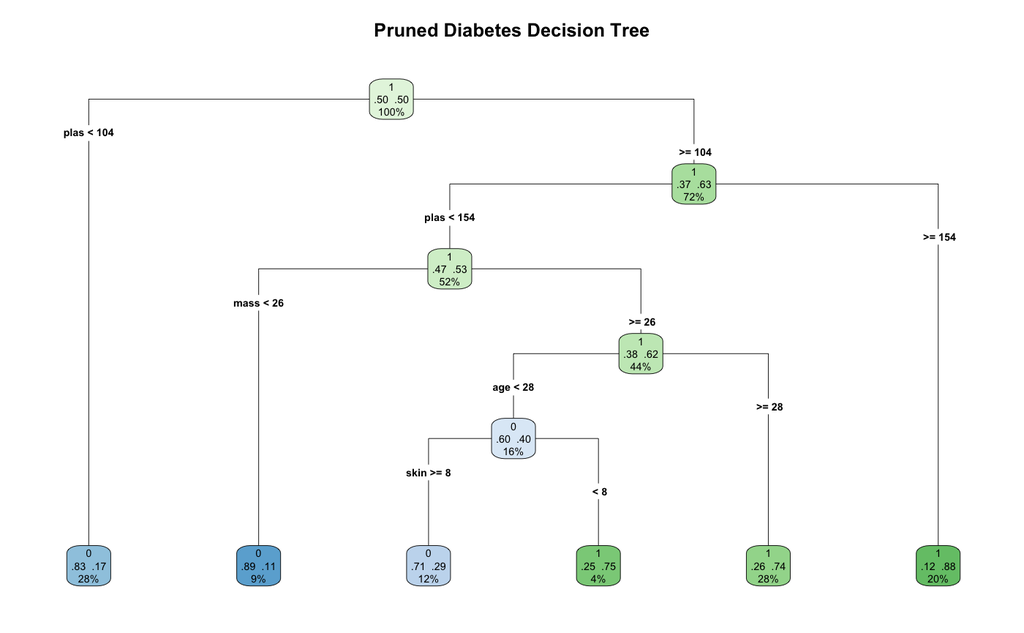

```r
ptree <- prune(model, cp=cpx)
rpart.plot(ptree, extra=104, fallen.leaves = T, type=4, main="Pruned Diabetes Decision Tree")
```

#### Hmmm, the tree is a bit less complex than the initial tree we had. So far, so good.

#### How does the pruned tree perform on predictions? Let’s see…

```r
ptree.pred <- predict(ptree, test, type="class")
confusionMatrix(ptree.pred, test[, 9])
```

```
Confusion Matrix and Statistics

          Reference
Prediction  0  1
         0 43 12
         1 12 40

               Accuracy : 0.776
                 95% CI : (0.685, 0.851)
    No Information Rate : 0.514
    P-Value [Acc > NIR] : 2.2e-08

                  Kappa : 0.551
 Mcnemar's Test P-Value : 1

            Sensitivity : 0.782
            Specificity : 0.769
         Pos Pred Value : 0.782
         Neg Pred Value : 0.769
             Prevalence : 0.514
         Detection Rate : 0.402
   Detection Prevalence : 0.514
      Balanced Accuracy : 0.776

       'Positive' Class : 0
```

#### Looks like we have done better than before. In our earlier confusion matrix, we had an accuracy of 0.748, sensitivity of 0.709 and specificity of 0.788. In our pruned tree, we have an increased accuracy (0.776), increased sensitivity (0.782), though a decreased specificity (0.769), i.e., we have increased our TPs at the expense of our TN.

#### And finally, let’s see if we improved our AUC with the pruned tree:

```r
pruned.pred.rocr <- predict(ptree, newdata=test, type="prob")[,2]
f.pruned.pred <- prediction(pruned.pred.rocr, test$label)
auc.pruned <- performance(f.pruned.pred, measure = "auc")
cat(paste("The area under curve (AUC) for the prunded tree is ", round(auc.pruned@y.values[[1]], 3)))
```

```
The area under curve (AUC) for the prunded tree is  0.837
```

#### We see a slight improvement for AUC in the prunded tree. Before, the AUC was 0.835, it is now 0.837.